# Stem-and-Leaf and Boxplot Graph

2025-01-31

**Stem-and-Leaf and Boxplot Graph**

##### Assign the score values of both genders into variables “Female” and “Male”

```r
Female <- c(57, 59, 78, 79, 60, 65, 68, 71, 75, 48, 51, 55, 56, 41, 43, 44, 75, 78, 80, 81, 83, 83, 85)
Male <- c(48, 49, 49, 30, 30, 31, 32, 35, 37, 41, 86, 42, 51, 53, 56, 42, 44, 50, 51, 65, 67, 51, 56, 58, 64, 64, 75)
```

### **Part A: Form the stem-and-leaf display for each gender, and discuss the advantages of this representation compared to the traditional histogram.**

#### **Female Stem-and-Leaf**

```r
stem(Female)
```

```
##
##   The decimal point is 1 digit(s) to the right of the |
##
##   4 | 1348
##   5 | 15679
##   6 | 058
##   7 | 155889
##   8 | 01335
```

#### **Male Stem-and-Leaf**

```r
stem(Male)
```

```
##
##   The decimal point is 1 digit(s) to the right of the |
##
##   3 | 001257
##   4 | 1224899
##   5 | 01113668
##   6 | 4457
##   7 | 5
##   8 | 6
```

##### Both the stem-and-leaf and histogram visualize the distribution of a set of data within a range. Despite this, the advantages of the representation in the stem-and-leaf is that you can see the **exact data values** and not just grouped within a range of numbers. With this, the **repetition or frequency of specific numbers** in the data can also be seen. For example, in the traditional histogram, the bar could show a range between numbers 40 and 49, which means that it could contain all numbers from 40 to 49, but with the stem-and-leaf, the actual values are revealed.

### **Part B: Construct a box-plot for each gender and discuss the findings.**

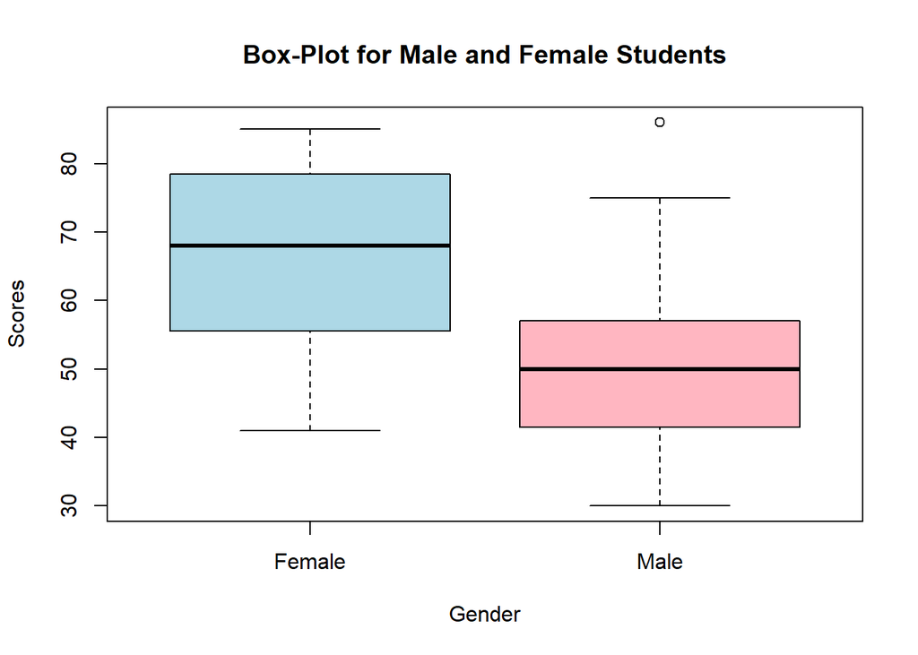

```r
scores <- data.frame(
  score = c(Male, Female),
  gender = factor(c(rep("Male", length(Male)), rep("Female", length(Female))))
)

boxplot(score ~ gender, data = scores,
        main = "Box-Plot for Male and Female Students",
        xlab = "Gender",
        ylab = "Scores",
        col = c("lightblue", "lightpink"))
```

##### As this reveals the box plot for both female and male scores, let us interpret and compare them. Firstly, it shows that the median of the female scores is slightly below 70, while the males’ are close to 50, indicating that **females, on average, scored higher than males**. As for the spread of the scores determined by the interquartile range (IQR), which is indicated by the areas with color, it shows how there is **more variation among the female scores compared to the male score**. Additionally, **an outlier in the male box plot is evident with a value of 86**, the highest score among the 50 students. This points out an **unusually extreme score in comparison to the rest of the male scores**. To summarize the findings, the box plot highlights that **females have more variability in their scores and tend to score higher on average than males, whose scores are more clustered at the lower end**.